# REDES BOOLEANAS

2026-02-09

estos son comentarios # siempre comentar cada linea de codigo lo mas detalladamente para saber donde estamos para cargar nuestros ficheros: getwd(“Documents/biologia_de_sistemas_posgrado/material_redes_booleanas/”) windows: setwd(“C:/Users/”)

cargar libreria boolnet podemos instalarla desde linea de comandos de R linea de comando install.packages(“boolnet”) o desde Rstudio (packages, install, nombre del paquete “boolnet”)

boolnet, tiene una seria de funciones escritas para llevar a cabo analisis de redes booleanas.cargaremos nuestra red de juguete que no es más que un archivo de texto plano, con extensión “.txt”

```r
net <- loadNetwork("/Volumes/alex/BS_scripts_clase/boolean-2026/Tutorial_Boolean_network_biology_systems-2026/red_ejemplo.txt")
net
```

```
## Boolean network with 3 genes
##
## Involved genes:
## a b c
##
## Transition functions:
## a = a
## b = a & ! c
## c = c & ! b
```

net, nos permitira ver las caracteristcas del fichero el interprete de R nos muestra el archivo la primera linea tiene que decir: targets, factor targets: son las variables independientes cuidado: no dejar espacios en blanco al final de cada linea.

si quisieramos ver la red, el dibujo del cual partimos (la abstracción del sistema)

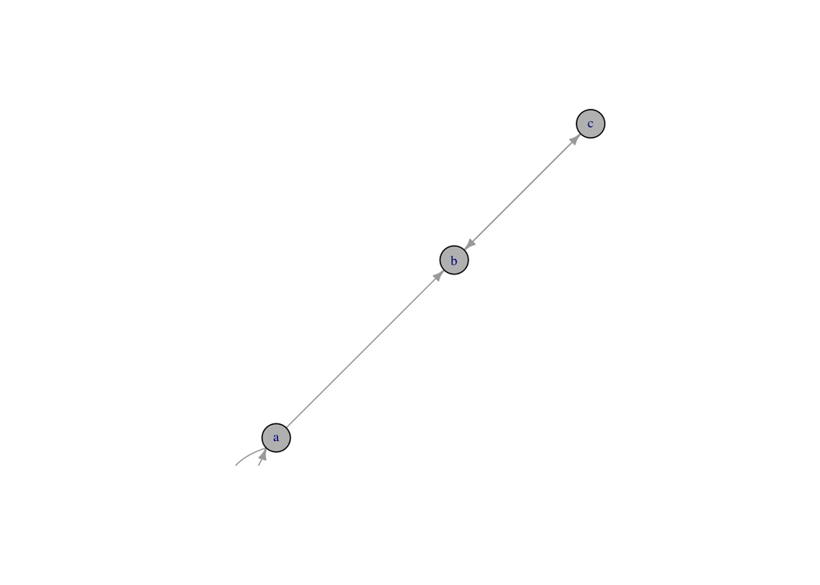

```r
plotNetworkWiring(net)
```

##

podeis observar que, el input se ve como un auto-loop para decirnos que, “a” al tiempo (t) más 1, es igual “a” al tiempo (t)

para ver la configuración de todos los atractores, utilizamos:

NOTA ATRACTORES:

SIMPLES: Los atractores simples se dan en redes booleanas síncronas y temporales y consisten en un conjunto de estados cuyas transiciones síncronas forman un ciclo.

COMPLEJOS: Los atractores complejos o laxos son la contrapartida de los atractores simples en las redes asíncronas. Como suele haber más de una transición posible para cada estado en una red asíncrona, un atractor complejo está formado por dos o más bucles superpuestos. Precisamente, un atractor complejo es un conjunto de estados en el que todas las transiciones de estado asíncronas conducen a otro estado del conjunto, y se puede llegar a un estado del conjunto desde todos los demás estados del conjunto.

Los atractores de estado estable son atractores que constan de un solo estado.

Todas las transiciones desde este estado conducen al propio estado.

Estos atractores son los mismos tanto para la actualización sincrónica como asincrónica de una red.

Los estados estacionarios son un caso especial tanto de los atractores simples como de los atractores complejos

La “función getAttractors()” incorpora varios métodos para la identificación de atractores en redes síncronas y asíncronas. Presentamos estos métodos utilizando como ejemplo la red del ciclo celular mam- maliano incluida.

```r
attr <- getAttractors(net)
attr
```

```
## Attractor 1 is a simple attractor consisting of 1 state(s) and has a basin of 3 state(s):
##
##  |--<--|
##  V     |
##  000   |
##  V     |
##  |-->--|
##
##
## Genes are encoded in the following order: a b c
##
## Attractor 2 is a simple attractor consisting of 1 state(s) and has a basin of 3 state(s):
##
##  |--<--|
##  V     |
##  110   |
##  V     |
##  |-->--|
##
##
## Genes are encoded in the following order: a b c
##
## Attractor 3 is a simple attractor consisting of 1 state(s) and has a basin of 1 state(s):
##
##  |--<--|
##  V     |
##  001   |
##  V     |
##  |-->--|
##
##
## Genes are encoded in the following order: a b c
##
## Attractor 4 is a simple attractor consisting of 1 state(s) and has a basin of 1 state(s):
##
##  |--<--|
##  V     |
##  101   |
##  V     |
##  |-->--|
##
##
## Genes are encoded in the following order: a b c
```

nos describe las caracteristicas de cada atractor. por ej: el atractor 1 (000) es de punto fijo, es decir: que consiste de un solo estado.

verlo de esta forma, no es muy intuitivo para ello, entonces utilizamos el sgte comando:

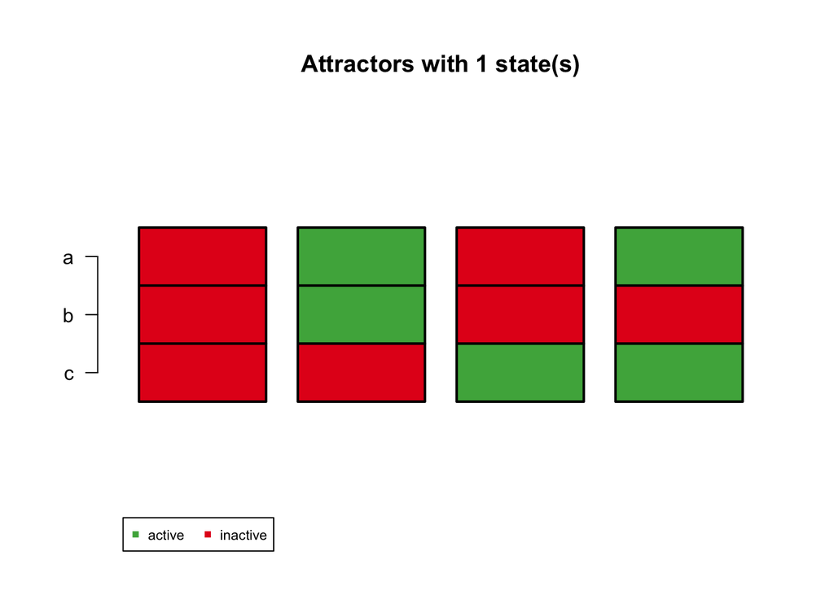

```
## $`1`
##   Attr1.1 Attr2.1 Attr3.1 Attr4.1
## a       0       1       0       1
## b       0       1       0       0
## c       0       0       1       1
```

```r
plotAttractors(attr)
```

otra alternativa es imprimir sólo los nombres de los genes activos (es decir, los genes que se establecen en 1) en lugar del vector completo llamando al método print()

```r
print(attr, activeOnly=TRUE)
```

```
## Attractor 1 is a simple attractor consisting of 1 state(s) and has a basin of 3 state(s).
## Active genes in the attractor state(s):
## State 1: --
##
## Attractor 2 is a simple attractor consisting of 1 state(s) and has a basin of 3 state(s).
## Active genes in the attractor state(s):
## State 1: a, b
##
## Attractor 3 is a simple attractor consisting of 1 state(s) and has a basin of 1 state(s).
## Active genes in the attractor state(s):
## State 1: c
##
## Attractor 4 is a simple attractor consisting of 1 state(s) and has a basin of 1 state(s).
## Active genes in the attractor state(s):
## State 1: a, c
```

La función getAttractorSequence() puede utilizarse para obtener la secuencia de estados que constituyen un atractor síncrono específico en forma de tabla

```r
getAttractorSequence(attr, 2)
```

```
##   a b c
## 1 1 1 0
```

si quisieramos ver un subset de nuestros atractores usamos: “subset= #”

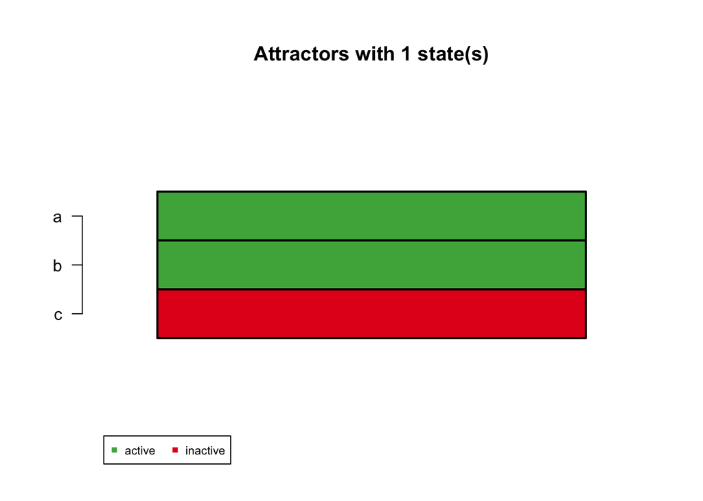

```
## $`1`
##   Attr2.1
## a       1
## b       1
## c       0
```

```r
plotAttractors(attr, subset=2)
```

búsqueda exhaustiva, aparte de los propios atractores, se calcula la tabla de transición completa

```r
tt <- getTransitionTable(attr)
tt
```

```
##   State     Next state  Attr. basin  # trans. to attr.
##     000 =>         000            1                  0
##     100 =>         110            2                  1
##     010 =>         000            1                  1
##     110 =>         110            2                  0
##     001 =>         001            3                  0
##     101 =>         101            4                  0
##     011 =>         000            1                  1
##     111 =>         100            2                  2
##
## Genes are encoded in the following order: a b c
```

Una tabla con la misma estructura es devuelta por

```r
getBasinOfAttraction(attr, 1)
```

```
##   State     Next state  Attr. basin  # trans. to attr.
##     000 =>         000            1                  0
##     010 =>         000            1                  1
##     011 =>         000            1                  1
##
## Genes are encoded in the following order: a b c
```

que extrae todos los estados de la tabla de transición que pertenecen a la cuenca de atracción del atractor uno (es decir, cuyo número de atractor en la columna 3 es 1). Si le interesa obtener información sobre un solo estado (en este caso, el estado en el que todos los genes están establecidos en 1), puede escribir:

```r
getStateSummary(attr, c(1,1,1))
```

```
##   State     Next state  Attr. basin  # trans. to attr.
##     111 =>         100            2                  2
##
## Genes are encoded in the following order: a b c
```

La función de visualización getStateGraph() también utiliza la tabla de transición: traza un gráfico de transición en el que las cuencas de atracción se dibujan en diferentes colores y los atractores se resaltan. El resultado de:

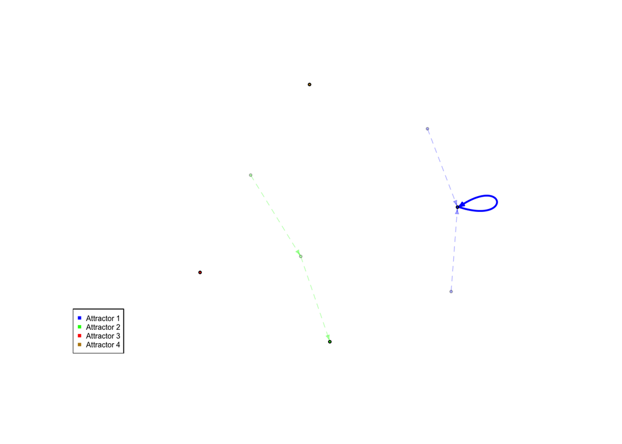

```r
plotStateGraph(attr)
```

##

La llamada anterior no garantiza que las cuencas de atracción estén claramente separadas en el gráfico. Si se desea, se puede optar por utilizar un diseño por partes, lo que significa que la función de diseño se aplica por separado a cada cuenca de atracción y las cuencas se dibujan una al lado de la otra. El resultado de

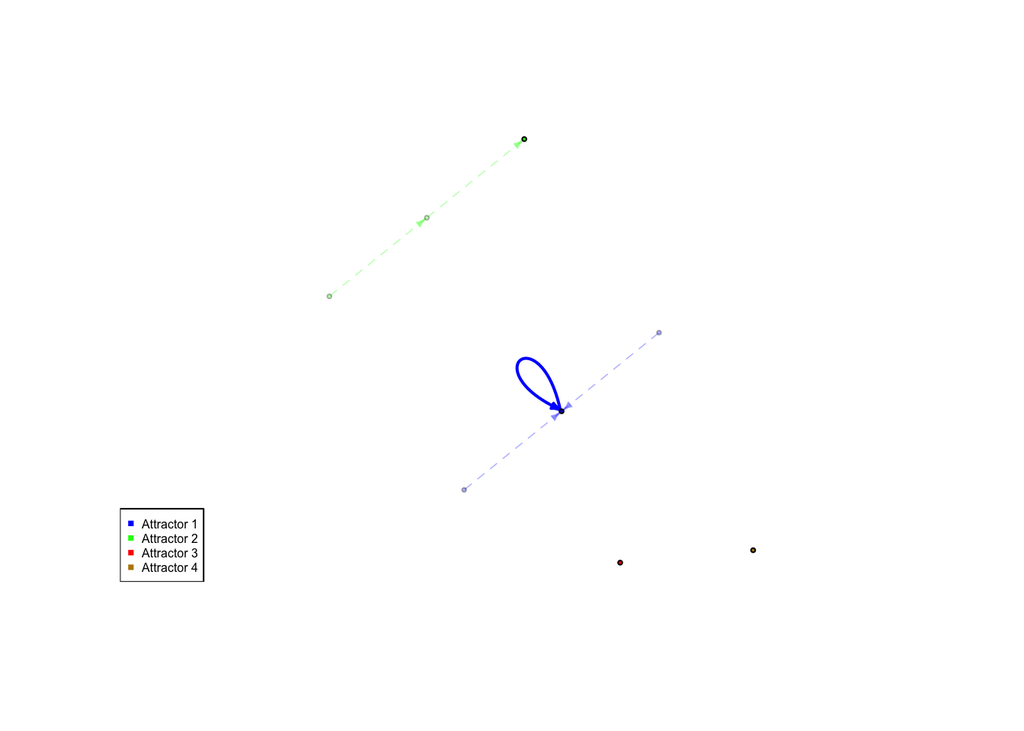

```r
plotStateGraph(attr, piecewise=TRUE)
```

##

Cada nodo representa un estado de la red, y cada flecha es una transición de estado. Los colores marcan diferentes cuencas de atracción. los atractores se resaltan con líneas en negrita.

PERTURBAR EL SISTEMA

```r
mut= getAttractors(net, genesOFF=c(0,0,1))
mut
```

```
## Attractor 1 is a simple attractor consisting of 1 state(s) and has a basin of 3 state(s):
##
##  |--<--|
##  V     |
##  000   |
##  V     |
##  |-->--|
##
##
## Genes are encoded in the following order: a b c
##
## Attractor 2 is a simple attractor consisting of 1 state(s) and has a basin of 1 state(s):
##
##  |--<--|
##  V     |
##  001   |
##  V     |
##  |-->--|
##
##
## Genes are encoded in the following order: a b c
```

resultado: obtenemos solo dos atractores y se pierden otros dos, luego de la perturbación de los nodos (genes) del sistema podemos visualizarlo de nuevo, para comprobar que es verdad.

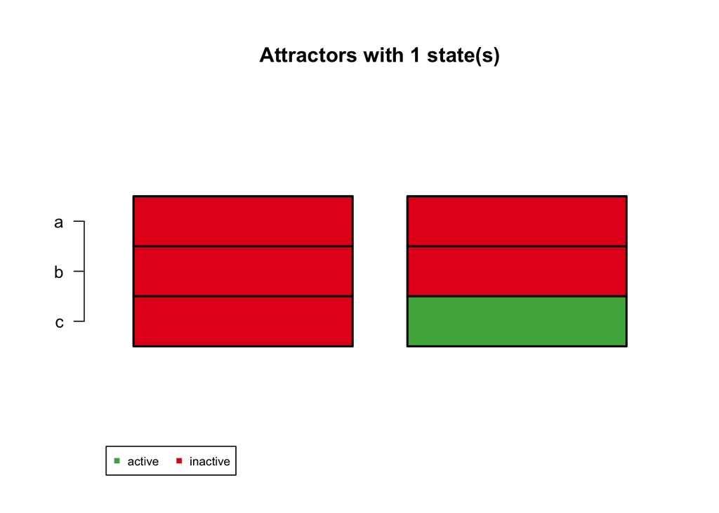

```
## $`1`
##   Attr1.1 Attr2.1
## a       0       0
## b       0       0
## c       0       1
```

```r
plotAttractors(mut)
```

si regresarmos a nuestra red silvestre, sin mutaciones,podemos preguntarnos, ¿a que atractor converjo cuando inicio en la condición inicial (1,0,0)

```r
getPathToAttractor(net, c(1,0,0))
```

```
##   a b c
## 1 1 0 0
## 2 1 1 0
```

nota: el tipo de reglas logicas utilizadas en nuestro ejemplo, es decir, la forma de actualizar nuestro sistema es forma sincrona (todos los nodosse actualizan al mismo tiempo). los nodos al tiempo (t) y al tiempo (t+1) responden al mismo tiempo. en getPathToAttractor(net, c(1,0,0)): 1 corresponde a (t) 2 corresponde a (t+1)

a b c 1 1 0 0 2 1 1 0

podriamos entonces, implementar metodos asincronos, es decir, pedir que las actualizacion se ejecuten de manera asincronica primero una regla y luego otra y así…actualizar un nodo y ver que ocurre. con boolnet, tambien lo podemos hacer para ver la robustez del sistema con ello, podriamos establecer si los actractores del sistemas son artefactos del metodo computacional. es decir, nos quedariamos con los actractores que son asincronos. esto es una forma de evaluar la robustez del sistema

podemos ejecutar entonces la sgte función en boolnet:

```r
att_asymchrom=getAttractors(net, type="asynchronous")
```

y luego:

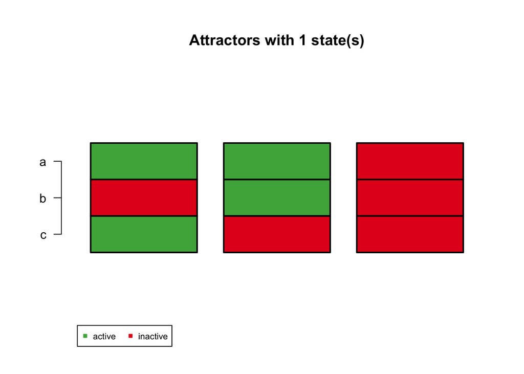

```
## $`1`
##   Attr1.1 Attr2.1 Attr3.1
## a       1       1       0
## b       0       1       0
## c       1       0       0
```

```r
plotAttractors(att_asymchrom)
```

para ver la configuración de los atractores podeis observar que, todo lo explicado manualmente en la clase anterior lo podemos analizar rapidamente en “R”, tambien podemos canalizar redes mucho mas grandes, podemos simular perturbaciones, ver que pasa cuando cambiamos las reglas lógicas por ej: cambiar en esta red, el “and” por un “or” y ver que pasa. ver que tanto cambian los actractores, ver que tanto cambia el porcentaje de condiciones inicicales que convergen a un atractor “x”

ahora vosotros manipular el sistema y observad que pasa

AHORA VOSOTROS MODIFICAR LAS REGLAS LOGICAS, POR EJEMPLO EL “AND” POR EL “OR”DISCUTIR QUE PASA

AHORA PUEDES SEGUIR LOS PASOS ANTERIORES USANDO ESTE EJEMPLO DISPONIBLE DIRECTAMENTE DESDE BOOLNET:

```r
setwd(getwd())
```

```r
net <- loadNetwork("/Volumes/alex/BS_scripts_clase/boolean-2026/Tutorial_Boolean_network_biology_systems-2026/cellcycle.txt")
net
```

```
## Boolean network with 10 genes
##
## Involved genes:
## CycD Rb E2F CycE CycA p27 Cdc20 Cdh1 UbcH10 CycB
##
## Transition functions:
## CycD = CycD
## Rb = (! CycA & ! CycB & ! CycD & ! CycE) | (p27 & ! CycB & ! CycD)
## E2F = (! Rb & ! CycA & ! CycB) | (p27 & ! Rb & ! CycB)
## CycE = (E2F & ! Rb)
## CycA = (E2F & ! Rb & ! Cdc20 & ! (Cdh1 & UbcH10)) | (CycA & ! Rb & ! Cdc20 & ! (Cdh1 & UbcH10))
## p27 = (! CycD & ! CycE & ! CycA & ! CycB) | (p27 & ! (CycE & CycA) & ! CycB &! CycD)
## Cdc20 = CycB
## Cdh1 = (! CycA & ! CycB) | (Cdc20) | (p27 & ! CycB)
## UbcH10 = ! Cdh1 | (Cdh1 & UbcH10 & (Cdc20 | CycA | CycB))
## CycB = ! Cdc20 & ! Cdh1
```

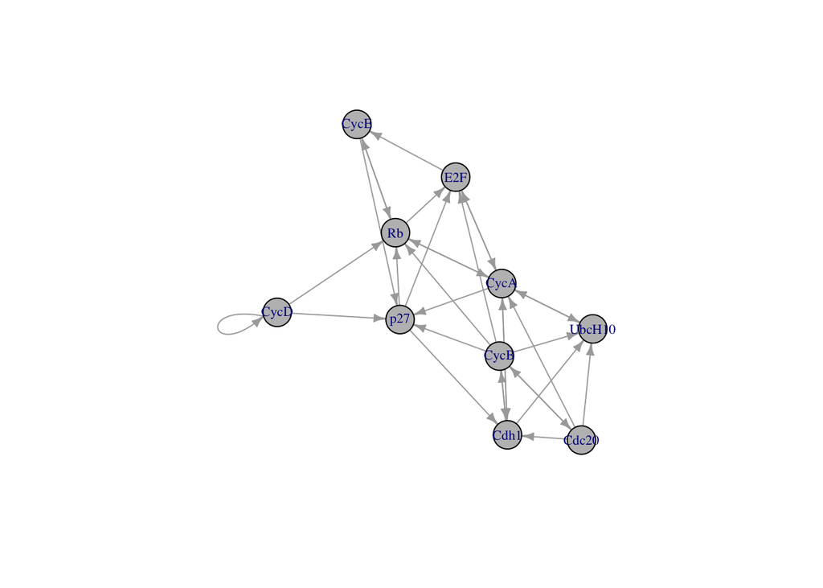

```r
plotNetworkWiring(net)
```

```r
attr <- getAttractors(net)
attr
```

```
## Attractor 1 is a simple attractor consisting of 1 state(s) and has a basin of 512 state(s):
##
##  |--<---------|
##  V            |
##  0100010100   |
##  V            |
##  |-->---------|
##
##
## Genes are encoded in the following order: CycD Rb E2F CycE CycA p27 Cdc20 Cdh1 UbcH10 CycB
##
## Attractor 2 is a simple attractor consisting of 7 state(s) and has a basin of 512 state(s):
##
##  |--<---------|
##  V            |
##  1001100000   |
##  1000100011   |
##  1000101011   |
##  1000001110   |
##  1010000110   |
##  1011000100   |
##  1011100100   |
##  V            |
##  |-->---------|
##
##
## Genes are encoded in the following order: CycD Rb E2F CycE CycA p27 Cdc20 Cdh1 UbcH10 CycB
```

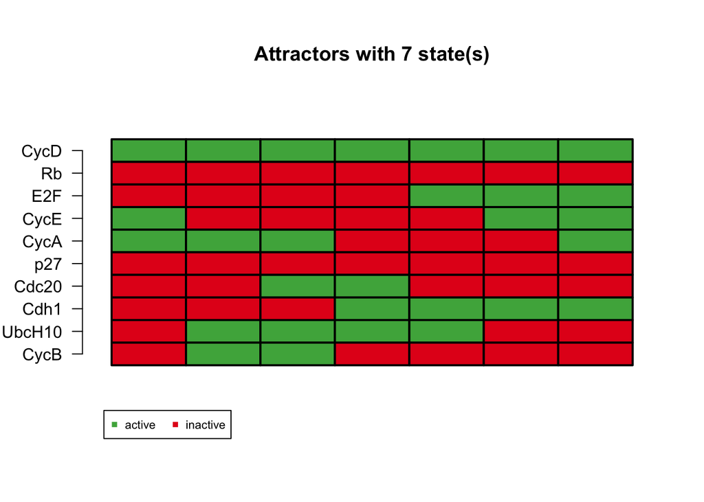

```
## $`1`
##        Attr1.1
## CycD         0
## Rb           1
## E2F          0
## CycE         0
## CycA         0
## p27          1
## Cdc20        0
## Cdh1         1
## UbcH10       0
## CycB         0
##
## $`7`
##        Attr2.1 Attr2.2 Attr2.3 Attr2.4 Attr2.5 Attr2.6 Attr2.7
## CycD         1       1       1       1       1       1       1
## Rb           0       0       0       0       0       0       0
## E2F          0       0       0       0       1       1       1
## CycE         1       0       0       0       0       1       1
## CycA         1       1       1       0       0       0       1
## p27          0       0       0       0       0       0       0
## Cdc20        0       0       1       1       0       0       0
## Cdh1         0       0       0       1       1       1       1
## UbcH10       0       1       1       1       1       0       0
## CycB         0       1       1       0       0       0       0
```

```r
plotAttractors(attr)
```

```r
print(attr, activeOnly=TRUE)
```

```
## Attractor 1 is a simple attractor consisting of 1 state(s) and has a basin of 512 state(s).
## Active genes in the attractor state(s):
## State 1: Rb, p27, Cdh1
##
## Attractor 2 is a simple attractor consisting of 7 state(s) and has a basin of 512 state(s).
## Active genes in the attractor state(s):
## State 1: CycD, CycE, CycA
## State 2: CycD, CycA, UbcH10, CycB
## State 3: CycD, CycA, Cdc20, UbcH10, CycB
## State 4: CycD, Cdc20, Cdh1, UbcH10
## State 5: CycD, E2F, Cdh1, UbcH10
## State 6: CycD, E2F, CycE, Cdh1
## State 7: CycD, E2F, CycE, CycA, Cdh1
```

```r
getAttractorSequence(attr, 2)
```

```
##   CycD Rb E2F CycE CycA p27 Cdc20 Cdh1 UbcH10 CycB
## 1    1  0   0    1    1   0     0    0      0    0
## 2    1  0   0    0    1   0     0    0      1    1
## 3    1  0   0    0    1   0     1    0      1    1
## 4    1  0   0    0    0   0     1    1      1    0
## 5    1  0   1    0    0   0     0    1      1    0
## 6    1  0   1    1    0   0     0    1      0    0
## 7    1  0   1    1    1   0     0    1      0    0
```

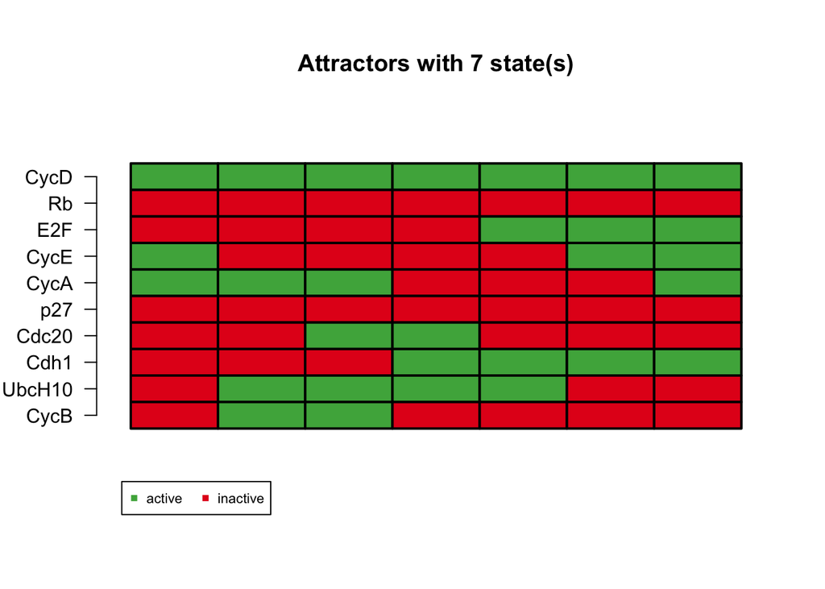

```
## $`1`
## NULL
##
## $`7`
##        Attr2.1 Attr2.2 Attr2.3 Attr2.4 Attr2.5 Attr2.6 Attr2.7
## CycD         1       1       1       1       1       1       1
## Rb           0       0       0       0       0       0       0
## E2F          0       0       0       0       1       1       1
## CycE         1       0       0       0       0       1       1
## CycA         1       1       1       0       0       0       1
## p27          0       0       0       0       0       0       0
## Cdc20        0       0       1       1       0       0       0
## Cdh1         0       0       0       1       1       1       1
## UbcH10       0       1       1       1       1       0       0
## CycB         0       1       1       0       0       0       0
```

```r
plotAttractors(attr, subset=2)
```

```r
tt <- getTransitionTable(attr)
tt
```

```
##      State      Next state  Attr. basin  # trans. to attr.
## 0000000000 =>   0110010111            1                  4
## 1000000000 =>   1010000111            2                  3
## 0100000000 =>   0100010111            1                  4
## 1100000000 =>   1000000111            2                  3
## 0010000000 =>   0111110111            1                  4
## 1010000000 =>   1011100111            2                  3
## 0110000000 =>   0100010111            1                  4
## 1110000000 =>   1000000111            2                  3
## 0001000000 =>   0010000111            1                  5
## 1001000000 =>   1010000111            2                  3
## 0101000000 =>   0000000111            1                  4
## 1101000000 =>   1000000111            2                  3
## 0011000000 =>   0011100111            1                  5
## 1011000000 =>   1011100111            2                  3
```

[output cut: 1012 more lines]

```r
getBasinOfAttraction(attr, 1)
```

```
##      State      Next state  Attr. basin  # trans. to attr.
## 0000000000 =>   0110010111            1                  4
## 0100000000 =>   0100010111            1                  4
## 0010000000 =>   0111110111            1                  4
## 0110000000 =>   0100010111            1                  4
## 0001000000 =>   0010000111            1                  5
## 0101000000 =>   0000000111            1                  4
## 0011000000 =>   0011100111            1                  5
## 0111000000 =>   0000000111            1                  4
## 0000100000 =>   0000100011            1                  5
## 0100100000 =>   0000000011            1                  5
## 0010100000 =>   0001100011            1                  5
## 0110100000 =>   0000000011            1                  5
## 0001100000 =>   0000100011            1                  5
## 0101100000 =>   0000000011            1                  5
```

[output cut: 500 more lines]

```r
getStateSummary(attr, c(1,1,1,1,1,1,1,1,1,1))
```

```
##      State      Next state  Attr. basin  # trans. to attr.
## 1111111111 =>   1000001110            2                  1
##
## Genes are encoded in the following order: CycD Rb E2F CycE CycA p27 Cdc20 Cdh1 UbcH10 CycB
```

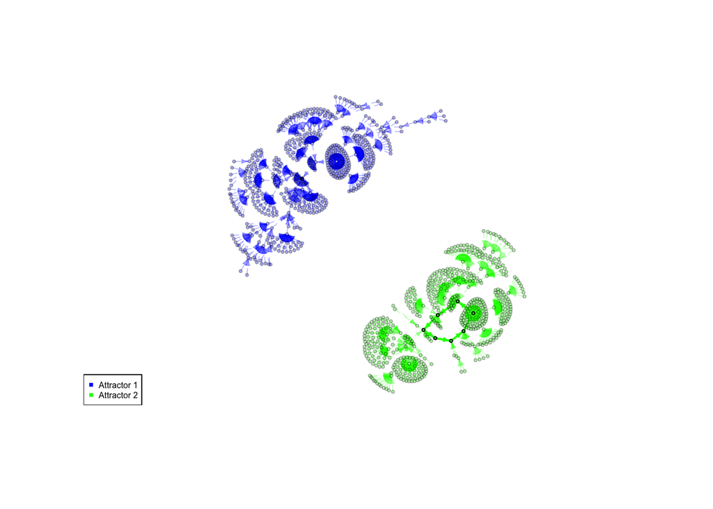

```r
plotStateGraph(attr)
```

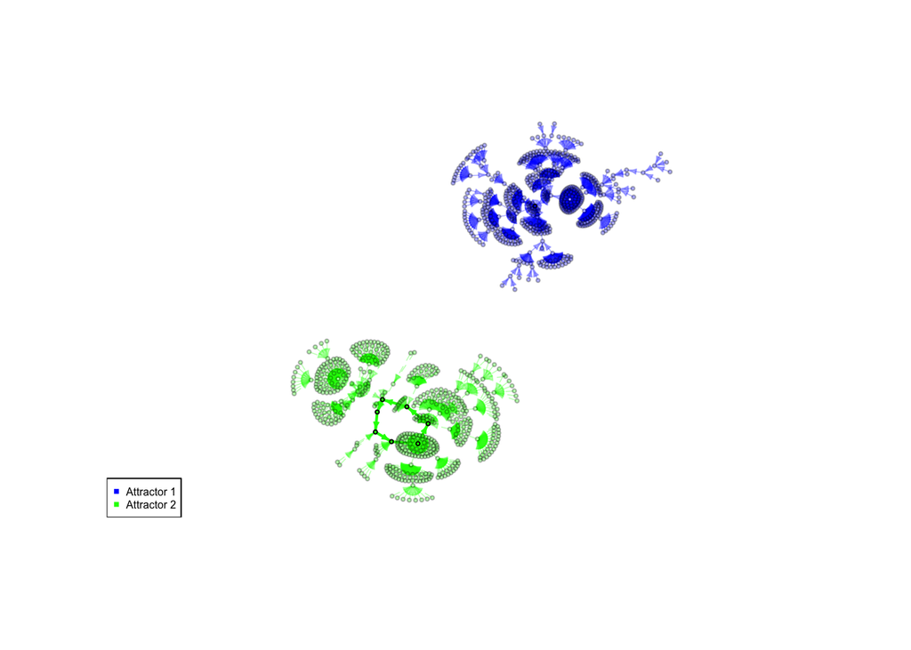

```r
plotStateGraph(attr, piecewise=TRUE)
```

```r
mut= getAttractors(net, genesOFF=c(0,0,1,1,1,0,1,1,1,1))
mut
```

```
## Attractor 1 is a simple attractor consisting of 1 state(s) and has a basin of 512 state(s):
##
##  |--<---------|
##  V            |
##  0100010100   |
##  V            |
##  |-->---------|
##
##
## Genes are encoded in the following order: CycD Rb E2F CycE CycA p27 Cdc20 Cdh1 UbcH10 CycB
```

```r
plotAttractors(mut)
```

```
## $`1`
##        Attr1.1
## CycD         0
## Rb           1
## E2F          0
## CycE         0
## CycA         0
## p27          1
## Cdc20        0
## Cdh1         1
## UbcH10       0
## CycB         0
```

```r
getPathToAttractor(net, c(1,1,1,1,1,1,1,1,1,1))
```

```
##   CycD Rb E2F CycE CycA p27 Cdc20 Cdh1 UbcH10 CycB
## 1    1  1   1    1    1   1     1    1      1    1
## 2    1  0   0    0    0   0     1    1      1    0
## 3    1  0   1    0    0   0     0    1      1    0
## 4    1  0   1    1    0   0     0    1      0    0
## 5    1  0   1    1    1   0     0    1      0    0
## 6    1  0   0    1    1   0     0    0      0    0
## 7    1  0   0    0    1   0     0    0      1    1
## 8    1  0   0    0    1   0     1    0      1    1
```

```r
att_asymchrom=getAttractors(net, type="asynchronous")
```

```r
plotAttractors(att_asymchrom)
```

```
## $`1`
##        Attr1.1
## CycD         0
## Rb           1
## E2F          0
## CycE         0
## CycA         0
## p27          1
## Cdc20        0
## Cdh1         1
## UbcH10       0
## CycB         0
```

https://sysbio.uni-ulm.de/?Software:ViSiBooL https://booleangenenetworks.math.iastate.edu/